# Contest Two

## Model Matrix

- Shifted classification by one
  - Maize is 0 (instead of 1)
  - Soil is 1 (instead of 2)
  - Weed is 2 (instead of 3)

| id | y | r0101 | r0201 | … | g1003 | g1103 | … | b3132 | b3232 |
| --- | --- | --- | --- | --- | --- | --- | --- | --- | --- |
| 1 | 1 | 0.5294118 | 0.5607843 | … | 0.1294118 | 0.1921569 | … | 0.4784314 | 0.3921569 |
| 2 | 2 | 0.6980392 | 0.6509804 | … | 0.7686275 | 0.7725490 | … | 0.5764706 | 0.5490196 |
| 3 | 1 | 0.4431373 | 0.5921569 | … | 0.8901961 | 0.5450980 | … | 0.5568627 | 0.5725490 |
| 4 | 2 | 0.5725490 | 0.3607843 | … | 0.4588235 | 0.2745098 | … | 0.3490196 | 0.4078431 |
| 5 | 2 | 0.1882353 | 0.0549020 | … | 0.2392157 | 0.2823529 | … | 0.1686275 | 0.2901961 |

## Model Selection

- Modeled the data by using multiple methods/classifiers
  - SVM with Linear and Radial Kernel
  - Random Forest
  - CNN (Highest Performing Model)
- Used cross validation for SVM and Random Forest models
  - Determine best model parameters
  - Prevent over fitting
  - Voting method

## Support Vector Machine

- Created SVM models using different kernels (Linear and Radial)
- Used the RGB values for each pixel as independent variables
- Models are trained with the whole training set
- RSE values are calculated using 30% of train set
- Cross validation was used to determine best hyperplanes given the entire training set

Results for different SVMs:

| Prediction | Package | Method | RES | Accuracy Score | Run Time |
| --- | --- | --- | --- | --- | --- |
| 1 | e1071 | SVM Radial | 0.0029 | 0.9267 | < 1 minute |
| 2 | caret | SVM Linear | 0.0 | 0.8967 | ~ 5 minutes |
| 3 | caret | SVM Radial | 0.0 | 0.9417 | > 15 minutes |

## Random Forest

- Feature Engineering
  - Created variables related to the average R, G, and B values
  - Created variables to the proportion of R to G to B values
  - Created variables for the ranges of the R, G, and B values
  - Created variables to determine which RGB value was greatest for a certain pixel
- Used cross validation to
  - Figure out the best mtry parameter
  - Perform voting on the test set
- Best model accuracy was 89% using this method

## Convolutional Neural Network (CNN)

- Model matrix setup using CNN:
  - Used entire training set to train the model
  - Converted RGB data of 1200 x 3072 into 1200 x 32 x 32 x 3 matrix array for input layer
  - Changed categorical results from 1, 2, 3 to 0, 1, 2 (reverted back to 1, 2, 3 for submission)
- CNN model setup:
  - Used 4 hidden layers
  - Used max pooling twice
  - Used 3 dropout layers (.25, .25, .5)
  - Flattened matrix pushed into dense layered for output
  - Did not use photo augmentation
- Parameter selection:
  - Epochs = **140**
  - Batch Size = **16**

## CNN - Model Assessment

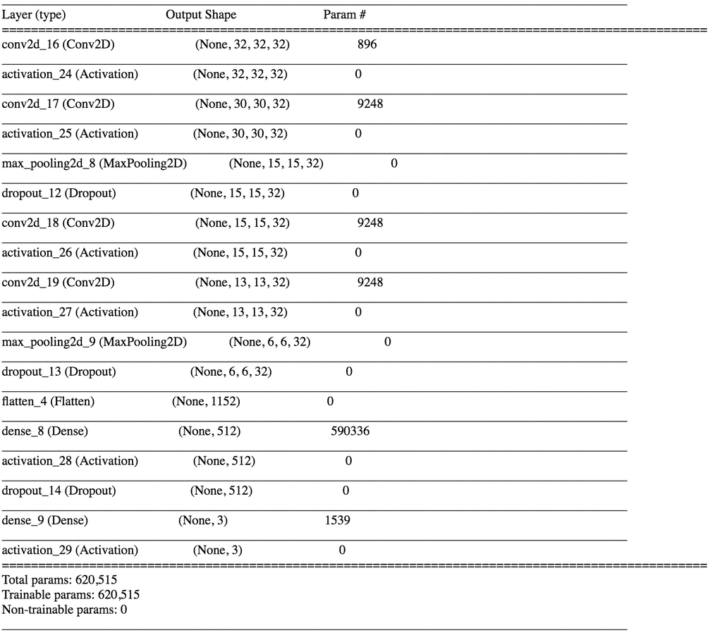

## CNN - Model Assessment

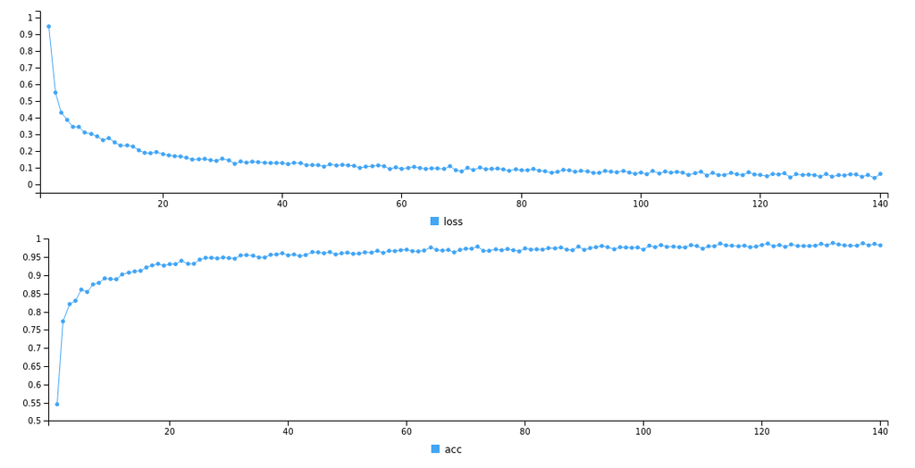

- Results of CNN model:
  - 98.3% on public leaderboard
  - 96.5% on private leaderboard